# Physiological and behavioral responses of the copepod Temora turbinata to hypoxia - ScienceDirect

## [Marine Pollution Bulletin](https://www-sciencedirect-com.reed.idm.oclc.org/journal/marine-pollution-bulletin)

[Volume 171](https://www-sciencedirect-com.reed.idm.oclc.org/journal/marine-pollution-bulletin/vol/171/suppl/C), October 2021, 112692

# Physiological and behavioral responses of the copepod *Temora turbinata* to hypoxia

https://doi.org/10.1016/j.marpolbul.2021.112692[Get rights and content](https://s100.copyright.com/AppDispatchServlet?publisherName=ELS&contentID=S0025326X21007268&orderBeanReset=true)

## Highlights

- •

  Physiological and behavioral responses of a subtropical calanoid copepod were tested in a short-term exposure to hypoxia.
- •

  There exists significant ontogenic variation in the hypoxia sensitivity in *Temora turbinata*.
- •

  Ingestion and respiration rates decreased with the decrease in DO level.
- •

  Female adults avoided the hypoxia layer in the artificial stratification column.

## Abstract

[Hypoxia](https://www-sciencedirect-com.reed.idm.oclc.org/topics/agricultural-and-biological-sciences/hypoxemia) is intensified in tropical and subtropical estuarine and coastal waters and brings about lethal and sublethal effects to marine copepods. The physiological and behavioral responses of the subtropical calanoid copepod *Temora turbinata* were tested after short-term exposure to hypoxia. The LD<sub>50</sub> values were 3.02 ± 0.21, 2.00 ± 0.35, and 3.11 ± 0.31 mg L<sup>−1</sup> for nauplii (II-III), copepodites (II-III), and female adults, respectively. With a decrease in the ambient dissolved oxygen (DO) level from 8 to 0.5 mg L<sup>−1</sup>, the ingestion rates decreased significantly at all life stages, as did oxygen consumption in female adults. In an artificial stratification column with a DO gradient, female adults exhibited an obvious avoidance response to the hypoxic bottom layer. Our study provides preliminary evidence for high hypoxia sensitivity in *T. turbinata* and implies that the DO level may be the main factor controlling the distribution of this species in tropical and subtropical coastal and estuarine waters.

## Keywords

Hypoxia

Mortality

Ingestion

Avoidance behavior

Respiration

Copepod

## 1. Introduction

[Hypoxia](https://www-sciencedirect-com.reed.idm.oclc.org/topics/agricultural-and-biological-sciences/hypoxemia) or anoxia occurs when the dissolved oxygen (DO) concentration of water is lower than 2.0 or equal to 0.0 mg L<sup>−1</sup> (Cooper and Brush, 1993; Diaz and Rosenberg, 1995). DO concentrations have been decreasing in global estuarine and coastal waters since the middle of last century, driven by eutrophication, global warming, and the stratification of water columns (Diaz and Rosenberg, 2008; Vaquer-Sunyer and Duarte, 2008; Rabalais et al., 2009; Breitburg et al., 2018). In many estuarine and coastal systems, including Chesapeake Bay, the northern Gulf of Mexico, Mirs Bay in South China, and the Yangtze [Estuary](https://www-sciencedirect-com.reed.idm.oclc.org/topics/agricultural-and-biological-sciences/estuaries), seasonal hypoxic zones usually form in summer with intensified stratification of water columns and other physical processes including winds, tides, and river flows (Boicourt, 1992; CENR, 2000; Chen et al., 2007; Li et al., 2014; Zhang et al., 2018). Furthermore, heavy nutrient loads that occur due to [anthropogenic activities](https://www-sciencedirect-com.reed.idm.oclc.org/topics/agricultural-and-biological-sciences/anthropogenic-activity) cause the frequency, magnitude, and extent of coastal hypoxia to increase in these areas (Luo et al., 2009; Wang et al., 2016; Shi et al., 2019).

Planktonic copepods play pivotal roles in pelagic food webs and are the main components of biological carbon pump. Species that are distributed in estuarine and coastal waters are characterized by high sensitivities to seasonal oxygen deficiencies compared with species distributed in [perennial](https://www-sciencedirect-com.reed.idm.oclc.org/topics/agricultural-and-biological-sciences/perennials) low-oxygen zones, which have developed adaption capabilities to low oxygen levels (Marcus, 2001; Rabalais et al., 2009). Tropical and subtropical species may be more easily constrained by oxygen deficiencies due to their high oxygen demands in warm waters. Nevertheless, some studies have demonstrated that the estuarine species *[Eurytemora affinis](https://www-sciencedirect-com.reed.idm.oclc.org/topics/agricultural-and-biological-sciences/eurytemora-affinis)* and *Pseudodiaptomus annandalei* adapt to living in high-density patches or within relatively narrow layers in estuarine waters where the oxygen levels can be very low or close to anoxic conditions; these studies provide clues on the low sensitivities of these species to DO deficits (Devreker et al., 2008; Dur et al., 2011; Chew et al., 2015). However, no attempt has been made to directly address the sensitivities of subtropical and tropical copepods to DO deficits. When seasonal hypoxia occurred during the southwestern monsoon in the waters along the southwest coast of India, indicator species, including typical subtropical and tropical species such as *[Acartia](https://www-sciencedirect-com.reed.idm.oclc.org/topics/agricultural-and-biological-sciences/acartia)* *erythraea*, *Centropages tenuiremis*, and *Temora turbinata*, exhibit decreased abundances, increased mortality rates, and varied proportions to the copepod community in response to seasonal hypoxia. This finding should be associated with the lethal and sublethal impacts of hypoxia on individual copepod species, but intricate interactions among different factors should also contribute to these observations in situ (Jyothibabu et al., 2018). Therefore, well-controlled laboratory studies are worthwhile to separate these individual factors and provide more explicit explanations.

Hypoxia has multiple detrimental impacts on individual marine organisms. The effects of DO levels generally follow the typical profiles of essential resources (Brett, 1979; Elliott et al., 2013). The mortality of copepods is caused by a dissolved oxygen level lower than the minimum level (level of no excessive activity) necessary for the maintenance of basic metabolism. When the DO level falls between the minimum and critical levels (*P*<sub>*crit*</sub>, threshold oxygen level for maximum performance), the growth, development, physiology, and behavior of copepods will be altered to certain extents, which are DO-level-dependent (Brett, 1979). Some studies have reported that the respiration rates are correlated with DO levels in a simple or segmented linear manner, which may be associated with the different respiration adaptation ability of the organisms concerned during hypoxia (oxyregulator or oxycomformer, Heisey and Porter, 1977; Grieshaber et al., 1988; Artigaud et al., 2014). The tolerance of copepods to DO deficits exhibits inter- and intro-specific differences, but controversy exists regarding the influence of ontogeny (Roman et al., 1993; Stalder and Marcus, 1997; Wang et al., 2013). DO levels in the range of 0.4–1.4 mg L<sup>−1</sup> were fatal to *[Acartia tonsa](https://www-sciencedirect-com.reed.idm.oclc.org/topics/agricultural-and-biological-sciences/acartia-tonsa)* female adults but had no effect on eggs or nauplii (Stalder and Marcus, 1997), whereas *A. tonsa* and *[Calanus](https://www-sciencedirect-com.reed.idm.oclc.org/topics/agricultural-and-biological-sciences/calanus)* *sinicus* showed decreased hatching rates at DO levels <2.0 mg L<sup>−1</sup> before the female adults began to die (Roman et al., 1993; Wang et al., 2013). In addition, hypoxia tolerance is also gender-dependent (Barba, 2015). Under low DO conditions, inter- or intra-specific differences in hypoxia sensitivity will cause shifts in the community and population to less sensitive species and developmental stages (Breitburg et al., 2018), and eventually, the food web structures and biogeochemical processes will be changed (de Mutsert et al., 2016). While all of the previous relevant studies have focused on temperate species (Roman et al., 1993; Wang et al., 2013; Barba, 2015), much less is known about the influences of hypoxia on subtropical and tropical copepod species.

The calanoid copepod *Temora turbinata*, a dominant planktonic calanoid species present in global subtropical and tropical estuarine and coastal waters, is critical to food web functions, nutrient biogeochemistry, and a vital food source to [fish larvae](https://www-sciencedirect-com.reed.idm.oclc.org/topics/agricultural-and-biological-sciences/fish-larvae) (Tseng et al., 2008a, Tseng et al., 2008b; de Oliveira Soaresa et al., 2018; Jagadeesan et al., 2019). The presence of this species is usually associated with upwelling waters, which generally induce hypoxia at the bottom of the waters (Liao et al., 2006; Jyothibabu et al., 2018; Jemi and Hatha, 2019). To fill the knowledge gap on the influences of hypoxia on subtropical and tropical copepods, the physiological and behavioral responses of the species, including its survival, ingestion, respiration and avoidance, were measured at different ontogenic stages. Two hypotheses were proposed: 1) *T. turbinata* is physiologically and behaviorally sensitive to hypoxia and; 2) there exists an ontogenic variation in [physiological responses](https://www-sciencedirect-com.reed.idm.oclc.org/topics/agricultural-and-biological-sciences/physiological-response) of *T. turbinata* to DO deficits.

## 2. Materials and methods

### 2.1. Zooplankton and preys

The planktonic copepod *Temora turbinata* was isolated from coastal waters in Daya Bay in the northern South China Sea and had been maintained in the laboratory for one year. In the laboratory, the animals were raised in 0.22-μm filtered sea water at a temperature of 20 ± 1 °C and a light cycle of 12 h light:12 h darkness, with an algal mixture of *[Tetraselmis](https://www-sciencedirect-com.reed.idm.oclc.org/topics/agricultural-and-biological-sciences/tetraselmis)* *subcordiformis,* *[Isochrysis galbana](https://www-sciencedirect-com.reed.idm.oclc.org/topics/agricultural-and-biological-sciences/isochrysis-galbana)**, and* *[Chlorella vulgaris](https://www-sciencedirect-com.reed.idm.oclc.org/topics/agricultural-and-biological-sciences/chlorella-vulgaris)* as their diet at a saturating food concentration. Their offspring resulting after 10 generations were used for experiments. All three algal preys were cultured in a f/2 medium (Guillard and Ryther, 1962) made of artificial sea water (Cavanaugh, 1956) at 20 ± 1 °C under a light cycle of 12 h light:12 h darkness. The light intensity was set at 100 μmol m<sup>−2</sup> s<sup>−1</sup>. Algal cells at the exponential growth stage were harvested by centrifugation at 15 °C for 15–20 min at 3000 rpm.

### 2.2. Ingestion rate

The ingestion rates of copepods at different developmental stages were determined at three DO levels, 2.0 ± 0.2, 4.0 ± 0.5 and 8.0 ± 0.5 mg L<sup>−1</sup>, in quintuplicate gas-tight glass bottles. Each gas-tight glass bottle containing 30 mL of sterilized filtered sea water at the desired DO levels with the initial food concentration adjusted to a saturation level of 2.4 × 10<sup>4</sup> cells mL<sup>−1</sup> received 20 nauplii (NII-III), 15 copepodites (CII-III), or 10 female adults. Two bottles with only food suspension were used as controls for each DO level. Copepods were fed a unialgal diet of *T. subcordiformi*, which had been harvested by centrifugation. The algal cells were killed by heating at 65 °C for 30 s and then resuspended in artificial sea water (ASW) as the food stock. The feeding lasted 6 h in darkness at 20 °C with the bottles installed on a rotating plankton wheel (0.8 rpm). At the end of the experiment, the DO levels were examined again. The contents of the bottles were filtered through 60-μm filters, and the filtrates were preserved with acid Lugol solution. The animals remaining on the filters were resuspended in ASW in petri dishes, and the numbers of live and dead individuals were counted under a stereomicroscope. The cell density was counted with a 0.1 mL plankton frame under an inverted microscope. The ingestion rate (IR, mg C ind<sup>−1</sup> h<sup>−1</sup>) was calculated by applying the decrease method according to Frost (1972) as follows (Eq. (1)):(1)$IR=V∙lnCt−lnCtf∙Ctf−C0N∙lnCtf−lnC0∙t$where *V* is the volume of seawater in the experimental tubes, *N* is the number of copepods (mean of the initial and final number of alive individuals), *C*<sub>*0*</sub> and *C*<sub>*tf*</sub> are the concentrations of algal cells before and after feeding, respectively, *C*<sub>*t*</sub> is the final algal concentration in each control tube, and *t* is the feeding time.

### 2.3. Mortality

The DO levels for the mortality experiment included 0.7 ± 0.2, 1.4 ± 0.2, 2.8 ± 0.2, 4.2 ± 0.5, 5.6 ± 0.5 and 7.0 ± 0.5 mg L<sup>−1</sup>, with four replicate gas-tight glass bottles used for each experiment. Each bottle was filled with 30 mL of sterilized sea water, and the seawater was bubbled with nitrogen to the desired DO concentrations. Each gas-tight glass bottle containing 30 mL of filtered sea water at desired DO levels with the initial food concentration adjusted to 2.4 × 10<sup>4</sup> cells mL<sup>−1</sup> received 20 nauplii (NII-III), 15 copepodites (CII-III), or 10 female adults. The bottles were sealed and mounted on a plankton wheel that rotated at 0.8 rpm, and the wheel was then placed in darkness at 20 °C. The incubation lasted for 24 h. When the experiment ended, the DO level of each bottle was determined again. Finally, the animals were poured into petri dishes, and the numbers of live and dead individuals were counted under a stereomicroscope. Any copepod not actively swimming and not responsive to gentle prodding by a needle probe was classified as dead.

### 2.4. Respiration

The oxygen concentrations were measured in this study using a Unisense oxygen electrode (OX-MR-711063 from Unisense, Aarhus, Denmark) connected to a Picoammeter (DK-8200 from Unisense, Aarhus, Denmark) at each time point, and calibrated to 100% and 0% oxygen concentrations by bubbling with atmospheric air and nitrogen gas beforehand, respectively.

### 2.5. Behavioral avoidance

One hundred and twenty female adults were randomly and evenly distributed to 8 beakers for acclimation for 2 h before the experiments were conducted. In each of 4 rectangular acrylic aquaria (5 × 5 × 28 cm, wall thickness of 2 mm), a stratified water column with three discrete layers was created using differences in salinity of 1 to 2 psu and varying temperatures. Three layers with different salinities, DO concentrations, and temperatures (Table 1) were prepared by slowly filling the aquarium with the corresponding ASW using a Nikon pipette placed just beneath the surface. The middle normoxic layer was lightly dyed red, and the bottom layer contained heat-killing prey at 2.4 × 10<sup>4</sup> cells mL<sup>−1</sup>. Four control aquaria were filled with normoxic ASW (DO = 5 mg L<sup>−1</sup>) at different salinities and temperatures and were stratified in the manner as the same as the experimental aquaria. Then, 20 copepods were placed at the surface of the water column one by one, and the aquaria were placed in darkness. The positions of all copepods were monitored every 1 min in dim light, and no obvious changes were observed in their distribution after 20 min. Therefore, the distribution of copepods was noted, and the number of individuals was counted after 30 min.

Table 1. Conditions of the stratified water columns used for the avoidance experiment of *T. turbinata*.

| Layer | DO (mg L<sup>−1</sup>) | Salinity (‰) | Temperature (°C) | Depth (cm) |
| --- | --- | --- | --- | --- |
| Upper | 5 | 29 | 30 | 13 |
| Middle | ≤5.0 | 30 | 25 | 2 |
| Bottom | ≤1.0 | 32 | 20 | 13 |

### 2.6. Statistical analysis

One-way ANOVA with Tukey's post hoc test was performed to compare the differences in respiration and behavioral avoidance to hypoxia among the DO levels, while two-way ANOVA was performed to test the interaction of effects between life stage and DO level on mortality and ingestion, both followed by a Tukey's post hoc test (SPSS 22.0). The percentage of copepod distribution was arcsine square root-transformed before the statistical analysis was run. The significance level was set <0.05.

## 3. Results

### 3.1. Mortality

The survival of *T. turbinata* varied with developmental life stage and DO level (Fig. 1). Nauplii and female adults showed almost total death (96–100%) at a DO level of 0.7 mg L<sup>−1</sup>, whereas copepodites maintained 20% survival at this level. Based on the regression between mortality and DO concentration conducted with the Probit model, nauplii and female adults shared comparable half-lethal DO levels (LC<sub>50</sub>, 3.02 ± 0.21 vs. 3.11 ± 0.31 mg L<sup>−1</sup>; *p* > 0.05), both of which were significantly higher than that of copepodites (Fig. 1; 2.00 ± 0.35 mg L<sup>−1</sup>; *p* = 0.001, one-way ANOVA and Turkey's post hoc test).

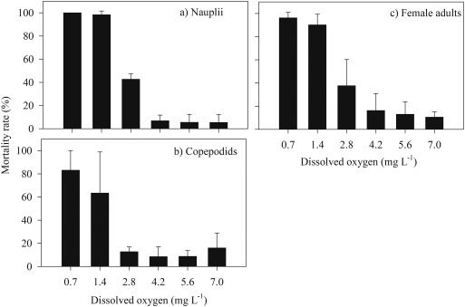

1. [Download: Download high-res image (170KB)](https://ars-els-cdn-com.reed.idm.oclc.org/content/image/1-s2.0-S0025326X21007268-gr1_lrg.jpg)
2. [Download: Download full-size image](https://ars-els-cdn-com.reed.idm.oclc.org/content/image/1-s2.0-S0025326X21007268-gr1.jpg)

Fig. 1. Mortality rates of a) naplii, b) copepodites, and c) female adults of *Temora turbinata* at different dissolved oxygen levels. (Means ± SD, *n* = 4).

### 3.2. Ingestion rate

The ingestion rate significantly increased with increasing DO concentration and developmental stage (both *p* < 0.001; two-way ANOVA). There was no significant interaction between these two factors, indicating that the effect of DO concentration is independent of the developmental stage (*p* = 0.098, two-way ANOVA; Fig. 2). Linear relationships generally existed between the IR and DO concentration in each developmental life stage (*p* < 0.0045, Pearson's analysis), with comparable slopes obtained among the developmental life stages (Fig. 2; *p* = 0.302, one-way ANOVA and Tukey's post hoc tests), also when pooling all life stages (*p* = 0.007, Pearson's analysis).

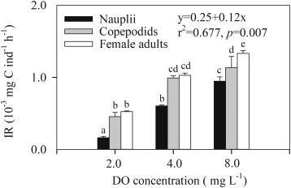

1. [Download: Download high-res image (122KB)](https://ars-els-cdn-com.reed.idm.oclc.org/content/image/1-s2.0-S0025326X21007268-gr2_lrg.jpg)
2. [Download: Download full-size image](https://ars-els-cdn-com.reed.idm.oclc.org/content/image/1-s2.0-S0025326X21007268-gr2.jpg)

Fig. 2. [Ingestion](https://www-sciencedirect-com.reed.idm.oclc.org/topics/agricultural-and-biological-sciences/ingestion) rates of naplii, copepodites, and female adults of *Temora turbinata* on *T. subcordiformis* at different DO concentrations and the equation indicating the relationship between the ingestion rate and the DO concentration (Means ± SD, *n* = 5; different lowercase letters indicate significant differences among the treatments).

### 3.3. Respiration

The respiration rate of *T. turbinata* decreased from 0.647 ± 0.199 to 0.017 ± 0.001 μg O<sub>2</sub> ind.<sup>−1</sup> h<sup>−1</sup> when the DO concentration decreased from 8.0 ± 0.5 to 0.5 ± 0.2 mg L<sup>−1</sup> (Fig. 3). At the highest DO level, the animals exhibited the higher respiration rate compared with other treatments (*p* = 0.001, one-way ANOVA, Tukey's post hoc test), and no significant difference was indicated among the four lower DO conditions (*p* > 0.05, one-way ANOVA, Tukey's post hoc test). A clear trend was shown in the variation in respiration along the hypoxia gradient, complying with a linear relationship (Fig. 3; *p* < 0.001; Pearson's analysis).

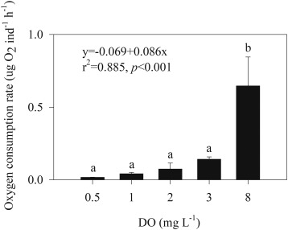

1. [Download: Download high-res image (103KB)](https://ars-els-cdn-com.reed.idm.oclc.org/content/image/1-s2.0-S0025326X21007268-gr3_lrg.jpg)
2. [Download: Download full-size image](https://ars-els-cdn-com.reed.idm.oclc.org/content/image/1-s2.0-S0025326X21007268-gr3.jpg)

Fig. 3. Respiration rates of adult *Temora turbinata* at different DO concentrations and the equation indicating the relationship between the respiration rate and the DO concentration (Means ± SD, *n* = 4).

### 3.4. Behavioral avoidance

In the experimental columns, the majority (>80%) of animals were distributed in the upper and transitional layers with normal DO concentrations, whereas 20% of animals were observed in the bottom layer with the low DO concentration (Fig. 4). This pattern was significantly different from that seen in the normoxic water column, where nearly 70% of animals were observed in the bottom layer where food particles were available, and 30% were observed in the upper layer (*p* ≤ 0.001, one-way ANOVA), which demonstrates that the severe thermal and salinity gradients did not affect the responses of the animals to the gradient of DO levels. No significant difference was detected in the distribution of animals in the transitional layers between treatments (*p* = 0.52; one-way ANOVA).

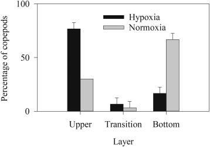

1. [Download: Download high-res image (90KB)](https://ars-els-cdn-com.reed.idm.oclc.org/content/image/1-s2.0-S0025326X21007268-gr4_lrg.jpg)
2. [Download: Download full-size image](https://ars-els-cdn-com.reed.idm.oclc.org/content/image/1-s2.0-S0025326X21007268-gr4.jpg)

## 4. Discussion

The physiological and behavioral responses of the subtropical copepod species *Temora turbinata* to hypoxia in a very preliminary form were examined for the first time in this study. The experiments were performed in a relatively short period of time (30 min ~ 24 h) with no or short periods (<2 h) of acclimation to hypoxia beforehand, corresponding to the situation of abrupt spatial and temporal variations in ambient oxygen levels, which are encounter by this species, as an indicator organisms in upwelling waters along the coasts of the Indian Sea and South China Sea (Jyothibabu et al., 2018; Zhang et al., 2018; Jemi and Hatha, 2019). Although the results reflect the short-term and episodic effects of hypoxia on *T. turbinata*, comparison of their responses to hypoxia with those of other species to acute hypoxia exposure in the following paragraphs suggests that this species is innately vulnerable to hypoxia.

The half-lethal DO levels ranged from 2.0– 3.1 mg L<sup>−1</sup> for *T. turbinata*. Most calanoid copepod species, including *Calanoides carinatus*, *Labidocera aestiva*, and *[Acartia tonsa](https://www-sciencedirect-com.reed.idm.oclc.org/topics/agricultural-and-biological-sciences/acartia-tonsa)**,* sustain their survival at DO levels above 1.4 mg O<sub>2</sub> L<sup>−1</sup> in the literature (Stalder and Marcus, 1997; Auel and Verheye, 2007). Therefore, *T. turbinata* appears more sensitive to hypoxia at all life stage. Some species, such as *[Calanus](https://www-sciencedirect-com.reed.idm.oclc.org/topics/agricultural-and-biological-sciences/calanus)* *sinicus*, however, are extremely sensitive to hypoxia, as their half-lethality level is as high as 3.0– 4.0 mg O<sub>2</sub> L<sup>−1</sup> (Wang et al., 2013). Nauplii and female adults exhibited higher hypoxia sensitivity than copepodites in our study. Comparably, a field work by Elliott and Tang (2011) revealed that younger nauplii (NI-NIII) and adult male *A. tonsa* individuals had higher percentages of deaths than older nauplii (NIV-NVI) or copepodites due to environmental stressors (~30% vs. 14%), wherein a weak positive correlation existed between the abundance of nauplii *A. tonsa* and the ambient DO concentration. Egg hatching rates were more susceptible to hypoxia than adult *A. tonsa* or *C. sincus* individuals (Roman et al., 1993; Wang et al., 2013). In contrast, a study by Stalder and Marcus (1997) revealed that DO levels in the range of 0.34– 0.71 mg L<sup>−1</sup> had no effect on the egg hatching rate or survival of nauplii *A. tonsa* but caused total death in female adults. However, it is noteworthy that only nauplii and copepodid at Stage NII-III and CII-CIII were chosen in our study, and therefore, refining the [ontogenic](https://www-sciencedirect-com.reed.idm.oclc.org/topics/agricultural-and-biological-sciences/ontogeny) resolution to include age-within-stage in the future studies will provide a clearer picture of sensitivity of this species to hypoxia. Low tolerance to low DO concentrations in young nauplii may ascribed to their high energy demand considering weight-specific metabolic rate usually decreased with increasing [body weight](https://www-sciencedirect-com.reed.idm.oclc.org/topics/agricultural-and-biological-sciences/body-weight). Meanwhile, it may also be associated with their undeveloped hearts with inefficient oxygen circulation (Ruz et al., 2018). However, more efforts are needed to study the underlying physiological and molecular mechanisms.

Hypoxia reduces feeding activity in many aquatic crustaceans. The ingestion rate of *T. turbinata* deceased by 60– 83% when the ambient DO concentration shifted from 8.0 to 2.0 mg L<sup>−1</sup>. At the same range of DO concentrations as that used in our study, the ingestion rate was reduced by 71% in *A. tonsa* (Elliott et al., 2013), whereas [cladoceran](https://www-sciencedirect-com.reed.idm.oclc.org/topics/agricultural-and-biological-sciences/cladocera) *[Moina micrura](https://www-sciencedirect-com.reed.idm.oclc.org/topics/agricultural-and-biological-sciences/moina-micrura)* stopped filtration when the DO level was as low as 0.7–0.8 mg O<sub>2</sub> L<sup>−1</sup> (Svetlichny and Hubareva, 2002). Furthermore, a significant positive linear correlation existed between the ingestion rate and DO concentration in *T. turbinata*, which is comparable to that reported for *[Daphnia galeata](https://www-sciencedirect-com.reed.idm.oclc.org/topics/agricultural-and-biological-sciences/daphnia-galeata)* and [Pacific oyster](https://www-sciencedirect-com.reed.idm.oclc.org/topics/agricultural-and-biological-sciences/pacific-oyster) (Heisey and Porter, 1977; Le Moullac et al., 2007) but different from the rectilinear changing mode observed in the filtration rate with an increase in DO concentration in *D. magna* (Heisey and Porter, 1977) or the sigmoid mode observed in barnacle and grooved carpet shells (Sobral and Widdows, 1997; Desai and Prakash, 2009). Conspicuously, the ingestion response to hypoxia is species-specific and correspondingly reflects the hypoxia sensitivity of a species. On the other hand, the linear mode may correspond to a higher sensitivity of *T. turbinate* than those of other marine invertebrates, which, with their rectilinear and sigmoidal response modes, are capable of maintaining consumption at different ambient DO levels.

The respiration rate decreased by 78% when the DO concentration shifted from normoxic (8.0 mg L<sup>−1</sup>) to the LC<sub>50</sub> level (3 mg L<sup>−1</sup>) for female adults, and it continued to decrease by 19% at the lethal level for total death (0.5 mg L<sup>−1</sup>). Alteration of the DO level from 8.0 to 2 mg L<sup>−1</sup> led to decreases of 61% and 89% in the ingestion rate and respiration rate, respectively, indicating that respiration was more susceptible to hypoxia than ingestion. Hypoxia suppresses other processes, such as growth and assimilation, in addition to ingestion, and, according to the bioenergetics of copepods (Kiørboe et al., 1985), the energy costs associated with growth and assimilation constitute the majority of the specific dynamic activity, while a much lower energy cost is linked to ingestion. Hypoxia constrains the respiration of animals and thus energy-fueling grazing and swimming activities, which may conversely help animals reduce energy costs as an adaptation to hypoxia. Forage efforts may be reduced by a decrease in the limb beat frequency or the ratio between stationary periods and swimming bouts in this continuously swimming species with feeding appendages under oxygen-deficient conditions.

The significant positive linear correlation observed between the respiration rate and ambient DO level indicates the hypoxia sensitivity of *T. turbinata*. The response modes of physiological processes to the DO level are species-specific in [aquatic invertebrates](https://www-sciencedirect-com.reed.idm.oclc.org/topics/agricultural-and-biological-sciences/aquatic-invertebrate), as are ingestion rates. The simple linear correlation presented in our study is similar to that found for *D. galeata* (Heisey and Porter, 1977) but is different from the segmented linear, hyperbolic or rectilinear pattern reported for *D. magna*, marine bivalves, or mussels (Bayne and Livingstone, 1977; Heisey and Porter, 1977; Wang and Widdows, 1991; Sobral and Widdows, 1997; Artigaud et al., 2014). The continuous decrease observed in the respiration rate with DO levels suggests that *T. turbinata* has a very high critical DO level (P<sub>c</sub>O<sub>2</sub>), corresponding to its high hypoxia sensitivity. The value should be higher than that for the more tolerant species *A. tonsa* (3.0– 4.2 mg L<sup>−1</sup> Elliott et al., 2013). Similar cases were observed for *D. galeata* and the bivalve *[Pecten maximus](https://www-sciencedirect-com.reed.idm.oclc.org/topics/agricultural-and-biological-sciences/pecten-maximus)* (Heisey and Porter, 1977; Artigaud et al., 2014)*,* and their oxygen consumption rates showed dose-effect responses at DO saturation levels close to 100%. In this sense, *T. turbinata* appears to be a perfect oxycoformer (Grieshaber et al., 1988).

## 5. Conclusions

The copepod *Temora turbinata* continuously reduced its ingestion rate and oxygen consumption by 60– 83% and 78– 97%, respectively, when the ambient DO level decreased from 8.0 to 0.5 mg L<sup>−1</sup>. In addition, obvious [avoidance behavior](https://www-sciencedirect-com.reed.idm.oclc.org/topics/agricultural-and-biological-sciences/avoidance-reaction) was observed in the hypoxic layer (1.0 mg L<sup>−1</sup>) in the water column. Ontogenic variation in the hypoxia sensitivity of this species was demonstrated, with lower LC<sub>50</sub> DO levels observed in copepodites (CII-III) than in nauplii (NII-III) and female adults. Overall, all findings point to high hypoxia sensitivities in this species and conform to its surface distribution pattern in tropical and subtropical coastal and estuarine waters. Owing to its adaption to wide ranges of temperatures and salinities, this species has become a successful [invasive species](https://www-sciencedirect-com.reed.idm.oclc.org/topics/agricultural-and-biological-sciences/invasive-species) around the world. However, expanding hypoxic conditions in marine systems will probably limit its dominance in the future, and a passing certain developmental life stage will become bottlenecks for its population development.

## CRediT authorship contribution statement

**Xuejia He:** Conceptualization, Methodology, Writing – review & editing. **Zhixian Pan:** Investigation, Data curation, Visualization. **Lu Zhang:** Investigation, Data curation, Visualization. **Didi Han:** Investigation, Data curation, Visualization.

## Declaration of competing interest

The authors declare that they have no known competing financial interests or personal relationships that could have appeared to influence the work reported in this paper.

## Acknowledgements

We thank the two reviewers for their very constructive comments. This research was supported by a grant from the Natural Science Foundation of Guangdong (No. 2021A1515011384) to X. He.

## References

1. Ara, 2002

   K. Ara

   Temporal variability and production of Temora turbinata (Copepoda: Calanoida) in the Cananeia Lagoon estuarine system, Sao Paulo, Brazil

   Sci. Mar., 66 (4) (2002), pp. 399-406

   [View at publisher](https://doi.org/10.3989/scimar.2002.66n4399)[Crossref](https://doi.org/10.3989/scimar.2002.66n4399)[View in Scopus](https://www.scopus.com/inward/record.url?eid=2-s2.0-0036994022&partnerID=10&rel=R3.0.0)Google Scholar
2. Artigaud et al., 2014

   S. Artigaud, C. Lacroix, V. Pichereau, J. Flye-Sainte-Marie

   Respiratory response to combined heat and hypoxia in the marine bivalves *Pecten maximus* and *Mytilus* spp

   Comp. Biochem. Physiol. A Mol. Integr. Physiol., 175 (2014), pp. 135-140, 10.1016/j.cbpa.2014.06.005

   [View PDF](https://www-sciencedirect-com.reed.idm.oclc.org/science/article/pii/S1095643314001184/pdfft?md5=9d8ce96b6c873f4a4c2bf217d69e672c&pid=1-s2.0-S1095643314001184-main.pdf)[View article](https://www-sciencedirect-com.reed.idm.oclc.org/science/article/pii/S1095643314001184)[View in Scopus](https://www.scopus.com/inward/record.url?eid=2-s2.0-84903480995&partnerID=10&rel=R3.0.0)Google Scholar
3. Auel and Verheye, 2007

   H. Auel, H.M. Verheye

   Hypoxia tolerance in the copepod *Calanoides carinatus* and the effect of an intermediate oxygen minimum layer on copepod vertical distribution in the northern Benguela Current upwelling system and the Angola-Benguela Front

   J. Exp. Mar. Biol. Ecol., 352 (2007), pp. 234-243

   [View PDF](https://www-sciencedirect-com.reed.idm.oclc.org/science/article/pii/S0022098107003826/pdfft?md5=a882f409dfe5a4cb421ebdf3196e5bf8&pid=1-s2.0-S0022098107003826-main.pdf)[View article](https://www-sciencedirect-com.reed.idm.oclc.org/science/article/pii/S0022098107003826)[View in Scopus](https://www.scopus.com/inward/record.url?eid=2-s2.0-35248812953&partnerID=10&rel=R3.0.0)Google Scholar
4. Barba, 2015

   A.P. Barba

   Thesis

   Response of the Copepod *Acartia tonsa* to Hypoxia in Chesapkeake Bay, University of Maryland Center for environmental Science (2015)

   [Google Scholar](https://scholar.google.com/scholar_lookup?title=Response%20of%20the%20Copepod%20Acartia%20tonsa%20to%20Hypoxia%20in%20Chesapkeake%20Bay&publication_year=2015&author=A.P.%20Barba)
5. Bayne and Livingstone, 1977

   B.L. Bayne, D.R. Livingstone

   Responses of Mytilus edulis L. to low oxygen tension: acclimation of the rate of oxygen consumption

   J. Comp. Physiol. B., 114 (1977), pp. 129-142, 10.1007/BF00688964

   [View at publisher](https://doi.org/10.1007/BF00688964)[View in Scopus](https://www.scopus.com/inward/record.url?eid=2-s2.0-0010487003&partnerID=10&rel=R3.0.0)Google Scholar
6. Boicourt, 1992

   W.C. Boicourt

   Influences of circulation processes on dissolved oxygen in the Chesapeake Bay

   D.E. Smith, M. Leffler, G. Mackiernan (Eds.), Oxygen Dynamics in the Chesapeake Bay: A Synthesis of Recent Researchy, Maryland Sea Grant Publication, College Park, MD (1992), pp. 7-59

   (Ca)

   [View in Scopus](https://www.scopus.com/inward/record.url?eid=2-s2.0-0002099212&partnerID=10&rel=R3.0.0)[Google Scholar](https://scholar.google.com/scholar_lookup?title=Influences%20of%20circulation%20processes%20on%20dissolved%20oxygen%20in%20the%20Chesapeake%20Bay&publication_year=1992&author=W.C.%20Boicourt)
7. Breitburg et al., 2018

   D. Breitburg, L.A. Levin, A. Oschlies, M. Grégoire, F.P. Chavez, D.J. Conley, V. Garçon, D. Gilbert, D. Gutiérrez, K. Isensee, *et al.*

   Declining oxygen in the global ocean and coastal waters

   Science, 359 (2018)

   (eaam7240)

   Google Scholar
8. Brett, 1979

   J.R. Brett

   Environmental factors and growth

   W.S. Hoar, D.J. Randall, J.R. Brett (Eds.), Fish Physiology, vol VIII, Academic Press, New York (1979), pp. 599-675

   [View PDF](https://www-sciencedirect-com.reed.idm.oclc.org/science/article/pii/S1546509808600333/pdfft?md5=64ebc7b8f838e1bccc5f9a0361db9395&pid=1-s2.0-S1546509808600333-main.pdf)[View article](https://www-sciencedirect-com.reed.idm.oclc.org/science/article/pii/S1546509808600333)[View in Scopus](https://www.scopus.com/inward/record.url?eid=2-s2.0-0642324924&partnerID=10&rel=R3.0.0)[Google Scholar](https://scholar.google.com/scholar_lookup?title=Environmental%20factors%20and%20growth&publication_year=1979&author=J.R.%20Brett)
9. Cavanaugh, 1956

   G.M. Cavanaugh

   Formulae and Methods V of the Marine Biological Laboratory Chemical Room

   Marine Biological Laboratory, Woods Hole, Massachusetts (1956), p. 84

   [Google Scholar](https://scholar.google.com/scholar_lookup?title=Formulae%20and%20Methods%20V%20of%20the%20Marine%20Biological%20Laboratory%20Chemical%20Room&publication_year=1956&author=G.M.%20Cavanaugh)
10. CENR (Committee on Environment and Natural Resources), 2000

    CENR (Committee on Environment and Natural Resources)

    Integrated Assessment of Hypoxia in the Northern Gulf of Mexico

    National Science and Technology Council Committee on Environment and Natural Resources, Washington, D.C (2000)

    Google Scholar
11. Chen et al., 2007

    C.-C. Chen, G.-C. Gong, F.-K. Shiah

    Hypoxia in the East China Sea: one of the largest coastal low-oxygen areas in the world

    Mar. Environ. Res., 64 (2007), pp. 399-408

    [View PDF](https://www-sciencedirect-com.reed.idm.oclc.org/science/article/pii/S0141113607000414/pdfft?md5=57bd021181bc8a22c96975b0843f5b2a&pid=1-s2.0-S0141113607000414-main.pdf)[View article](https://www-sciencedirect-com.reed.idm.oclc.org/science/article/pii/S0141113607000414)[View in Scopus](https://www.scopus.com/inward/record.url?eid=2-s2.0-34548126183&partnerID=10&rel=R3.0.0)Google Scholar
12. Chew et al., 2015

    L.L. Chew, V.C. Chong, A.I. Ooi, A. Sasekumar

    Vertical migration and positioning behavior of copepods in a mangrove estuary: interactions between tidal, diel light and lunar cycles

    Estuar. Coast. Shelf Sci., 152 (2015), pp. 142-152

    [View PDF](https://www-sciencedirect-com.reed.idm.oclc.org/science/article/pii/S0272771414003394/pdfft?md5=089a982e05bbc880ccc89e17b96c4423&pid=1-s2.0-S0272771414003394-main.pdf)[View article](https://www-sciencedirect-com.reed.idm.oclc.org/science/article/pii/S0272771414003394)[View in Scopus](https://www.scopus.com/inward/record.url?eid=2-s2.0-84918792577&partnerID=10&rel=R3.0.0)Google Scholar
13. Cooper and Brush, 1993

    S.R. Cooper, G.S. Brush

    A 2500-year history of anoxia and eutrophication in Chesapeake Bay

    Estuaries, 16 (3b) (1993), pp. 617-626

    [View at publisher](https://doi.org/10.2307/1352799)[Crossref](https://doi.org/10.2307/1352799)[Google Scholar](https://scholar.google.com/scholar_lookup?title=A%202500-year%20history%20of%20anoxia%20and%20eutrophication%20in%20Chesapeake%20Bay&publication_year=1993&author=S.R.%20Cooper&author=G.S.%20Brush)
14. de Mutsert et al., 2016

    K. de Mutsert, J. Steenbeek, K. Lewis, J. Buszowski, J.H. Cowan, V. Christensen

    Exploring effects of hypoxia on fish and fisheries in the northern Gulf of Mexico using a dynamic spatially explicit ecosystem model

    Ecol. Model., 331 (2016), p. 142e150

    Google Scholar
15. de Oliveira Soaresa et al., 2018

    M. de Oliveira Soaresa, C. Coelho Campos, N.M. Oliveira Santos, H. de Sousa Barroso, E.M.T. Mota, M.O.B. de Menezes, S. Rossi, T.M. Garcia

    Marine bioinvasions: differences in tropical copepod communities between inside and outside a port

    J. Sea Res., 134 (2018), pp. 42-48

    Google Scholar
16. Desai and Prakash, 2009

    D.V. Desai, S. Prakash

    Physiological responses to hypoxia and anoxia in Balanus amphitrite (Cirripedia: Thoracica)

    Mar. Ecol. Prog. Ser., 390 (2009), pp. 157-166

    [View at publisher](https://doi.org/10.3354/meps08155)[Crossref](https://doi.org/10.3354/meps08155)[View in Scopus](https://www.scopus.com/inward/record.url?eid=2-s2.0-70349547218&partnerID=10&rel=R3.0.0)[Google Scholar](https://scholar.google.com/scholar_lookup?title=Physiological%20responses%20to%20hypoxia%20and%20anoxia%20in%20Balanus%20amphitrite%20&publication_year=2009&author=D.V.%20Desai&author=S.%20Prakash)
17. Devreker et al., 2008

    D. Devreker, S. Souissi, J.C. Molinero, F. Nkubito

    Trade-offs of the copepod Eurytemora affinis in mega-tidal estuaries: insights from high frequency sampling in the seine estuary

    J. Plankton Res., 30 (2008), pp. 1329-1342

    View at publisher

    [Crossref](https://doi.org/10.1093/plankt/fbn086)[View in Scopus](https://www.scopus.com/inward/record.url?eid=2-s2.0-56749169579&partnerID=10&rel=R3.0.0)Google Scholar
18. Dias et al., 2018

    C.O. Dias, A.V. Araujo, S.L.C. Bonecker

    Vertical distribution and structure of copepod (Arthropoda: Copepoda) assemblages in two different seasons down to 1,200 m in the tropical Southwestern Atlantic

    Zoologia, 35 (2018)

    (e13886)

    Google Scholar
19. Diaz and Rosenberg, 1995

    R. Diaz, R. Rosenberg

    Marine benthic hypoxia: a review of its ecological effects and the behavioural responses of benthic macrofauna

    Oceanogr. Mar. Biol., 33 (1995), pp. 245-303

    Google Scholar
20. Diaz and Rosenberg, 2008

    R.J. Diaz, R. Rosenberg

    Spreading dead zones and consequences for marine ecosystems

    Science, 321 (5891) (2008), pp. 926-929

    [View at publisher](https://ct.prod.getft.io/c2NpZW5jZWRpcmVjdF9jb250ZW50aG9zdGluZyxhYWFzLGh0dHBzOi8vd3d3LnNjaWVuY2Uub3JnL2RvaS9lcGRmLzEwLjExMjYvc2NpZW5jZS4xMTU2NDAxP3NyYz1nZXRmdHI.UL59f-88A4e9Yfm1rlBfpNvWdlrfcakAGE4YjrmqFEg)

    [Crossref](https://doi.org/10.1126/science.1156401)[View in Scopus](https://www.scopus.com/inward/record.url?eid=2-s2.0-49649095625&partnerID=10&rel=R3.0.0)[Google Scholar](https://scholar.google.com/scholar_lookup?title=Spreading%20dead%20zones%20and%20consequences%20for%20marine%20ecosystems&publication_year=2008&author=R.J.%20Diaz&author=R.%20Rosenberg)
21. D'souza and Gauns, 2018

    A.M. D’souza, M. Gauns

    Spatial variability of copepod species distribution in the eastern Arabian Sea in pre-monsoon conditions

    Deep-Sea Res. Part II, 156 (2018), pp. 111-120

    [View PDF](https://www-sciencedirect-com.reed.idm.oclc.org/science/article/pii/S0967064517301777/pdfft?md5=4cfe35d75a3315a98bce1fe10aef595c&pid=1-s2.0-S0967064517301777-main.pdf)[View article](https://www-sciencedirect-com.reed.idm.oclc.org/science/article/pii/S0967064517301777)[View in Scopus](https://www.scopus.com/inward/record.url?eid=2-s2.0-85044984016&partnerID=10&rel=R3.0.0)Google Scholar
22. Dur et al., 2011

    G. Dur, S. Souissi, F.G. Schmitt, D. Beyrend-Dur, J.S. Hwang

    Mating and mate choice in Pseudodiaptomus annandalei (Copepoda Calanoida)

    J. Exp. Mar. Biol. Ecol., 402 (2011), pp. 1-11

    [View PDF](https://www-sciencedirect-com.reed.idm.oclc.org/science/article/pii/S0022098111000876/pdfft?md5=e9daaaeb1e743f57b8096d390589c67d&pid=1-s2.0-S0022098111000876-main.pdf)[View article](https://www-sciencedirect-com.reed.idm.oclc.org/science/article/pii/S0022098111000876)[View in Scopus](https://www.scopus.com/inward/record.url?eid=2-s2.0-79955716200&partnerID=10&rel=R3.0.0)Google Scholar
23. Elliott and Tang, 2011

    D.T. Elliott, K.W. Tang

    Influence of carcass abundance on estimates of mortality and assessment of population dynamics in *Acartia tonsa*

    Mar. Ecol. Prog. Ser., 427 (2011), pp. 1-12, 10.3354/meps09063

    [View at publisher](https://doi.org/10.3354/meps09063)[View in Scopus](https://www.scopus.com/inward/record.url?eid=2-s2.0-79954550075&partnerID=10&rel=R3.0.0)Google Scholar
24. Elliott et al., 2013

    D.T. Elliott, J.J. Pierson, M.R. Roman

    Predicting the effects of coastal hypoxia on vital rates of the planktonic copepod *Acartia tonsa* Dana

    PLoS One, 8 (5) (2013), Article e63987, 10.1371/journal.pone.0063987

    [View at publisher](https://doi.org/10.1371/journal.pone.0063987)[View in Scopus](https://www.scopus.com/inward/record.url?eid=2-s2.0-84877853659&partnerID=10&rel=R3.0.0)Google Scholar
25. Frost, 1972

    B. Frost

    Effects of size and concentration of food particles on the feeding behavior of the marine planktonic copepod *Calanus pacificus*

    Limnol. Oceanogr., 17 (1972), pp. 805-815

    (Gui)

    View at publisher

    [Crossref](https://doi.org/10.4319/lo.1972.17.6.0805)[View in Scopus](https://www.scopus.com/inward/record.url?eid=2-s2.0-84983864458&partnerID=10&rel=R3.0.0)Google Scholar
26. Grieshaber et al., 1988

    M.K. Grieshaber, U. Kreutzer, H.O. Pörtner

    Critical PO<sub>2</sub> of euryoxic animals

    H. Acker (Ed.), Oxygen Sensing in Tissues, Springer, Berlin Heidelberg (1988), pp. 37-48

    [View at publisher](https://doi.org/10.1007/978-3-642-83444-8_3)[Crossref](https://doi.org/10.1007/978-3-642-83444-8_3)[View in Scopus](https://www.scopus.com/inward/record.url?eid=2-s2.0-0007247959&partnerID=10&rel=R3.0.0)[Google Scholar](https://scholar.google.com/scholar_lookup?title=Critical%20PO2%20of%20euryoxic%20animals&publication_year=1988&author=M.K.%20Grieshaber&author=U.%20Kreutzer&author=H.O.%20P%C3%B6rtner)
27. Guillard and Ryther, 1962

    R.R.L. Guillard, J.H. Ryther

    Studies of marine planktonic diatoms. I. Cyclotella nana Hustedt and Detonula confervacea Cleve

    Can. J. Microbiol., 8 (1962), pp. 229-239

    [View at publisher](https://doi.org/10.1139/m62-029)[Crossref](https://doi.org/10.1139/m62-029)[View in Scopus](https://www.scopus.com/inward/record.url?eid=2-s2.0-73049174685&partnerID=10&rel=R3.0.0)Google Scholar
28. He et al., 2021

    X. He, Z. Wang, Z. Bai, L. Han, M. Chen

    Diel feeding rhythm and grazing selectivity of small-sized copepods in a subtropical embayment, the northern South China Sea

    Front. Mar. Sci., 8 (2021), Article 658664, 10.3389/fmars.2021.658664

    [View at publisher](https://doi.org/10.3389/fmars.2021.658664)[View in Scopus](https://www.scopus.com/inward/record.url?eid=2-s2.0-85108539002&partnerID=10&rel=R3.0.0)Google Scholar
29. Heisey and Porter, 1977

    D. Heisey, K. Porter

    The effect of ambient oxygen concentration on filtering and respiration rates of *Daphnia galeata* mendotae and *Daphnia magna*

    Limnol. Oceanogr., 22 (1977), pp. 839-845

    View at publisher

    [Crossref](https://doi.org/10.4319/lo.1977.22.5.0839)[View in Scopus](https://www.scopus.com/inward/record.url?eid=2-s2.0-84986793406&partnerID=10&rel=R3.0.0)Google Scholar
30. Hopcroft and Roff, 1998

    R.R. Hopcroft, J.C. Roff

    Zooplankton growth rates: the influence of size in nauplii of tropical marine copepodites

    Mar. Biol., 132 (1998), pp. 87-96

    [View in Scopus](https://www.scopus.com/inward/record.url?eid=2-s2.0-0031755638&partnerID=10&rel=R3.0.0)Google Scholar
31. Jagadeesan et al., 2019

    L. Jagadeesan, G. Sampath Kumar, D.N. Rao, N. Surendra babu, T.N.R. Srinivas

    Role of eddies in structuring the mesozooplankton composition in coastal waters of the western Bay of Bengal

    Ecol. Indic., 105 (2019), pp. 137-155

    [View PDF](https://www-sciencedirect-com.reed.idm.oclc.org/science/article/pii/S1470160X19304121/pdfft?md5=a9d3493b6178cfc0b15a5c4268931153&pid=1-s2.0-S1470160X19304121-main.pdf)[View article](https://www-sciencedirect-com.reed.idm.oclc.org/science/article/pii/S1470160X19304121)[View in Scopus](https://www.scopus.com/inward/record.url?eid=2-s2.0-85066328002&partnerID=10&rel=R3.0.0)Google Scholar
32. Jemi and Hatha, 2019

    J.N. Jemi, A.A.M. Hatha

    Copepod community structure during upwelling and non-upwelling seasons in coastal waters off Cochin, southwest coast of India

    Acta Oceanol. Sin., 38 (12) (2019), pp. 111-117, 10.1007/s13131-019-1491-6

    [View at publisher](https://doi.org/10.1007/s13131-019-1491-6)[View in Scopus](https://www.scopus.com/inward/record.url?eid=2-s2.0-85076890913&partnerID=10&rel=R3.0.0)Google Scholar
33. Jyothibabu et al., 2018

    R. Jyothibabu, L. Jagadeesan, C. Karnan, N. Arunpandi, R.S. Pandiyarajan, K.K. Balachandran

    Ecological indications of copepods to oxygen-deficient near-shore waters

    Ecol. Indic., 93 (2018), pp. 76-90

    [View PDF](https://www-sciencedirect-com.reed.idm.oclc.org/science/article/pii/S1470160X18303224/pdfft?md5=f895aa76d2a8e73c1c6cbb4ff27b2ba1&pid=1-s2.0-S1470160X18303224-main.pdf)[View article](https://www-sciencedirect-com.reed.idm.oclc.org/science/article/pii/S1470160X18303224)[View in Scopus](https://www.scopus.com/inward/record.url?eid=2-s2.0-85046352682&partnerID=10&rel=R3.0.0)Google Scholar
34. Kiørboe et al., 1985

    T. Kiørboe, F. Møhlenberg, K. Hamburger

    Bioenergetics of the planktonic copepod *Acartia tonsa*: relation between feeding, egg production and respiration, and composition of specific dynamic action

    Mar. Ecol. Prog. Ser., 26 (1985), pp. 85-97

    [View at publisher](https://doi.org/10.3354/meps026085)[Crossref](https://doi.org/10.3354/meps026085)Google Scholar
35. Lan et al., 2015

    Y.-C. Lan, K.-C. Liu, C.-T. Lee, C.-L. Wu, M.-A. Lee

    Spatial and temporal distribution of *Temora turbinata* in the Waters of the Tanshui River estuary

    J. Taiwan Fisheries Res., 23 (1) (2015), pp. 11-21

    (in Chinese)

    Google Scholar
36. Le Moullac et al., 2007

    G. Le Moullac, I. Quéau, P. Le Souchu, S. Pouvreau, J. Moal, J. René Le Coz, J. François Samain

    Metabolic adjustments in the oyster Crassostrea gigas according to oxygen level and temperature

    Mar. Biol. Res., 3 (2007), pp. 357-366, 10.1080/17451000701635128

    [View at publisher](https://doi.org/10.1080/17451000701635128)Google Scholar
37. Li et al., 2014

    X.-L. Li, H.-M. Shi, H.-Y. Xia, Y.-P. Zhou, Y.-W. Qiu

    Seasonal hypoxia and its potential forming mechanisms in the Mirs Bay, the northern South China Sea

    Cont. Shelf Res., 80 (2014), pp. 1-7

    [View PDF](https://www-sciencedirect-com.reed.idm.oclc.org/science/article/pii/S1046592814000990/pdfft?md5=90f59129bcd55e2673de4ca1a2ce505b&pid=1-s2.0-S1046592814000990-main.pdf)[View article](https://www-sciencedirect-com.reed.idm.oclc.org/science/article/pii/S1046592814000990)Google Scholar
38. Liao et al., 2006

    C.-H. Liao, W.-J. Chang, M.-A. Lee, K.-T. Lee

    Summer distribution and diversity of copepods in upwelling waters of the Southeastern East China Sea

    Zool. Stud., 45 (3) (2006), pp. 378-394

    [View in Scopus](https://www.scopus.com/inward/record.url?eid=2-s2.0-33749666651&partnerID=10&rel=R3.0.0)Google Scholar
39. López-Salgado and Suárez-Morales, 1998

    I. López-Salgado, E. Suárez-Morales

    Copepod assemblages in surface waters of the Western Gulf of Mexico

    Crustaceana, 71 (3) (1998), pp. 312-330

    [View at publisher](https://doi.org/10.1163/156854098X00284)[Crossref](https://doi.org/10.1163/156854098X00284)[View in Scopus](https://www.scopus.com/inward/record.url?eid=2-s2.0-0345244818&partnerID=10&rel=R3.0.0)Google Scholar
40. Luo et al., 2009

    L. Luo, S. Li, D. Wang

    Hypoxia in the Pearl River Estuary, the South China Sea, in July 1999

    Aquat. Ecosyst. Health Manag., 12 (2009), pp. 418-428, 10.1080/14634980903352407

    [View at publisher](https://doi.org/10.1080/14634980903352407)[View in Scopus](https://www.scopus.com/inward/record.url?eid=2-s2.0-77954756004&partnerID=10&rel=R3.0.0)Google Scholar
41. Marcus, 2001

    N.H. Marcus

    Zooplankton: Responses to and consequences of hypoxia

    N.N. Rabalais, R.E. Turner (Eds.), Coastal Hypoxia: Consequences for Living Resources and Ecosystems, Coast. Estuar. Stud, vol. 58, Am. Geophys. Union, Washington, DC (2001), pp. 49-60

    [Google Scholar](https://scholar.google.com/scholar_lookup?title=Zooplankton%3A%20Responses%20to%20and%20consequences%20of%20hypoxia&publication_year=2001&author=N.H.%20Marcus)
42. Márquez-Rojas et al., 2020

    B. Márquez-Rojas, L. Tróccoli, E.Z. de Roa

    Seasonal variation of the community of copepods in the eastern sector of the Gulf of Cariaco, Sucre state, Venezuela

    Bull. Mar. Coast. Res., 49 (1) (2020), pp. 113-134

    [View at publisher](https://doi.org/10.25268/bimc.invemar.2020.49.1.777)[Crossref](https://doi.org/10.25268/bimc.invemar.2020.49.1.777)[View in Scopus](https://www.scopus.com/inward/record.url?eid=2-s2.0-85091819931&partnerID=10&rel=R3.0.0)Google Scholar
43. Rabalais et al., 2009

    N.N. Rabalais, R.E. Turner, R.J. Díaz, D. Justiæ

    Global change and eutrophication of coastal waters

    ICES J. Mar. Sci., 66 (2009), pp. 1528-1537, 10.1093/icesjms/fsp047

    View at publisher

    [View in Scopus](https://www.scopus.com/inward/record.url?eid=2-s2.0-67649633508&partnerID=10&rel=R3.0.0)Google Scholar
44. Roman et al., 1993

    M.R. Roman, A.L. Gauzens, W.K. Rhinehart, J.R. White

    Effects of low oxygen waters on Chesapeake Bay zooplankton

    Limnol. Oceanogr., 38 (1993), pp. 1603-1614

    View at publisher

    [Crossref](https://doi.org/10.4319/lo.1993.38.8.1603)[View in Scopus](https://www.scopus.com/inward/record.url?eid=2-s2.0-0027329661&partnerID=10&rel=R3.0.0)Google Scholar
45. Ruz et al., 2018

    P.M. Ruz, P. Hidalgo, R. Escribano, J.E. Keister, L. Yebra, B. Franco-Cisternab

    Hypoxia effects on females and early stages of Calanus chilensis in the Humboldt Current ecosystem (23°S)

    J. Exp. Mar. Biol. Ecol., 498 (2018), pp. 61-71

    [View PDF](https://www-sciencedirect-com.reed.idm.oclc.org/science/article/pii/S0022098117302058/pdfft?md5=5de2680c5a02c7f95f76bc56b91b45e2&pid=1-s2.0-S0022098117302058-main.pdf)[View article](https://www-sciencedirect-com.reed.idm.oclc.org/science/article/pii/S0022098117302058)[View in Scopus](https://www.scopus.com/inward/record.url?eid=2-s2.0-85034431252&partnerID=10&rel=R3.0.0)Google Scholar
46. Shi et al., 2019

    Z. Shi, K. Liu, S. Zhang, H. X., H. Liu

    Estuarine, Coastal and Shelf Science. Spatial distributions of mesozooplankton biomass, community composition and grazing impact in association with hypoxia in the Pearl River Estuary

    Estuar. Coast. Shelf Sci., 225 (2019), Article 106,237.

    Google Scholar
47. Sobral and Widdows, 1997

    P. Sobral, J. Widdows

    Influence of hypoxia and anoxia on the physiological responses of the clam Ruditapes decussatus from southern Portugal

    Mar. Biol., 127 (1997), pp. 455-461, 10.1007/s002270050033

    [View at publisher](https://ct.prod.getft.io/c2NpZW5jZWRpcmVjdF9jb250ZW50aG9zdGluZyxzcHJpbmdlcixodHRwOi8vbGluay5zcHJpbmdlci5jb20vY29udGVudC9wZGYvMTAuMTAwNy9zMDAyMjcwMDUwMDMzLnBkZg.K2N5cMw94JCR_kilGjOJr4XLFrBWi9rwI-Un9CnxC2c)

    [View in Scopus](https://www.scopus.com/inward/record.url?eid=2-s2.0-0031046818&partnerID=10&rel=R3.0.0)Google Scholar
48. Stalder and Marcus, 1997

    L. Stalder, N. Marcus

    Zooplankton responses to hypoxia: behavioral patterns and survival of three species of calanoid copepods

    Mar. Biol., 127 (1997), pp. 599-607

    [View in Scopus](https://www.scopus.com/inward/record.url?eid=2-s2.0-0030973589&partnerID=10&rel=R3.0.0)Google Scholar
49. Sterza and Fernandes, 2006

    J.M. Sterza, L.L. Fernandes

    Zooplankton community of Vitoria Bay estuarine system (Southeastern Brazil). Characterization during a three-year study

    Braz. J. Oceanogr., 54 (2006), pp. 95-105

    [View in Scopus](https://www.scopus.com/inward/record.url?eid=2-s2.0-53149117649&partnerID=10&rel=R3.0.0)Google Scholar
50. Svetlichny and Hubareva, 2002

    L.S. Svetlichny, E.S. Hubareva

    Effect of oxygen concentration on metabolism and locomotory activity of *Moina micrura* (Cladocera) cultured under hypo- and normoxia

    Mar. Biol., 141 (1) (2002), pp. 145-151

    [View in Scopus](https://www.scopus.com/inward/record.url?eid=2-s2.0-0036938948&partnerID=10&rel=R3.0.0)Google Scholar
51. Tseng et al., 2008a

    L.-C. Tseng, H.-U. Dahms, Q.-C. Chen, J.-S. Hwang

    Copepod Assemblages of the Northern South China Sea

    Crustaceana, 81 (1) (2008), pp. 1-22

    [View at publisher](https://doi.org/10.1163/156854008783244753)[Crossref](https://doi.org/10.1163/156854008783244753)[View in Scopus](https://www.scopus.com/inward/record.url?eid=2-s2.0-37249093633&partnerID=10&rel=R3.0.0)Google Scholar
52. Tseng et al., 2008b

    L.C. Tseng, R. Kumar, H.U. Dahms, C.T. Chen, S. Souissi, Q.C. Chen, J.S. Hwang

    Copepod community structure over a marine outfall area in the north-eastern South China Sea

    J. Mar. Biol. Assoc. UK, 88 (2008), pp. 955-966

    [View at publisher](https://doi.org/10.1017/s0025315408001574)[Crossref](https://doi.org/10.1017/s0025315408001574)[View in Scopus](https://www.scopus.com/inward/record.url?eid=2-s2.0-48249088446&partnerID=10&rel=R3.0.0)Google Scholar
53. Vaquer-Sunyer and Duarte, 2008

    R. Vaquer-Sunyer, C.M. Duarte

    Thresholds of hypoxia for marine biodiversity

    Proc. Natl. Acad. Sci. U. S. A., 105 (2008), pp. 15,452-15,457

    [Google Scholar](https://scholar.google.com/scholar_lookup?title=Thresholds%20of%20hypoxia%20for%20marine%20biodiversity&publication_year=2008&author=R.%20Vaquer-Sunyer&author=C.M.%20Duarte)
54. Wang and Widdows, 1991

    W.X. Wang, J. Widdows

    Physiological responses of mussel larvae *Mytilus edulis* to environmental hypoxia and anoxia

    Mar. Ecol. Prog. Ser., 70 (1991), pp. 223-236

    [View at publisher](https://doi.org/10.3354/meps070223)[Crossref](https://doi.org/10.3354/meps070223)Google Scholar
55. Wang et al., 2013

    Q. Wang, T. Yan, M. Zhou

    The effects of hypoxia on survival and reproduction of *Calanus sinicus*

    Mar. Sci., 37 (2/2013) (2013), pp. 12-16

    (in Chinese).

    [View in Scopus](https://www.scopus.com/inward/record.url?eid=2-s2.0-84938566391&partnerID=10&rel=R3.0.0)Google Scholar
56. Wang et al., 2016

    H.J. Wang, M.H. Dai, J.W. Liu, S.-J. Kao, C. Zhang, W.-J. Cai, G.Z. Wang, W. Qian, M.X. Zhao, Z.Y. Sun

    Eutrophication-driven hypoxia in the east China Sea off the Changjiang estuary

    Environ. Sci. Technol., 50 (5) (2016), pp. 2255-2263

    [Crossref](https://doi.org/10.1021/acs.est.5b06211)[View in Scopus](https://www.scopus.com/inward/record.url?eid=2-s2.0-84959558295&partnerID=10&rel=R3.0.0)Google Scholar
57. Zhang et al., 2018

    H. Zhang, W. Cheng, Y. Chen, L. Yu, W. Gong

    Controls on the interannual variability of hypoxia in a subtropical embayment and its adjacent waters in the Guangdong coastal upwelling system, northern South China Sea

    Ocean Dyn., 68 (2018), pp. 923-938, 10.1007/s10236-018-1168-2

    [View in Scopus](https://www.scopus.com/inward/record.url?eid=2-s2.0-85048046313&partnerID=10&rel=R3.0.0)Google Scholar

## Cited by (2)

### [Copepoda community imprints the continuity of the oceanic and shelf oxygen minimum zones along the west coast of India](https://www-sciencedirect-com.reed.idm.oclc.org/science/article/pii/S0141113624000412)

- 2024, Marine Environmental Research

### [Impacts of hypoxia on the mesozooplankton community structure in a semi-enclosed bay](https://doi.org/10.3389/fmars.2022.1005442)

- 2022, Frontiers in Marine Science